# 82535_Kraśniewska_Kamila

Author

Kamila Kraśniewska (123019)

# 1 Wstęp

Informacje o wyniku na Kaggle:

- nick: kamilakrasniewska
- wynik: 96875.37

W ramach projektu zastosowano cztery metody: imputację dedukcyjną, imputację metodą k-najbliższych sąsiadów, imputację przy użyciu modelu logistycznego i predykcję przy użyciu lasu losowego. Informacje o metodach spoza zakresu zajęć pozyskano z:

1. Model logistyczny: [“Imputation in R: Top 3 Ways for Imputing Missing Data”](https://www.appsilon.com/post/imputation-in-r#missforest)
2. Las losowy: kurs na datacamp.com [“Handling Missing Data with Imputations in R”](https://app.datacamp.com/learn/courses/handling-missing-data-with-imputations-in-r)

W ramach projektu wykorzystano LLM ChatGPT do przyporządkowania nazw obszarów Poznania do oficjlanych nazw dzielnic miasta w możliwie największym stopniu. W tym celu wysłano zapytanie z załącznikiem zawierającym poprawne nazwy dzielnic i prośbą o przyporządkowanie tych potocznych nazw do nazw z pliku.

# 2 Metodyka

Projekt wykonano w języku R (wersja 4. 4. 2), korzystając z RStudio. Dane treningowe i testowe zostały połączone w jeden zbiór. W ramach pierwszego etapu dokonano eksploracji danych. Wykluczono występowanie zduplikowanych id oraz błędów w logice między datami aktywacji, modyfikacji i wygaśnięcia ogłoszeń. Znaleziono wartości puste w zbiorze danych i zastąpiono je przez “NA” dla ujednolicenia sposobu prezentacji braków. Następnie wykryto wartości odstające i nietypowe ze względu na charakter zmiennych. Po zbadaniu tych wartości te uznane za niepoprawne zmienione na braki danych.

W kolejnym etapie wyodrębniono zbiór danych bez tytułów ogłoszeń dla usprawnienia dalszych metod imputacji. Zastosowano imputację metodą k-najbliższych sąsiadów (k=3) do zaimputowania brakujących danych o dzielnicach. Następnie zbadano korelacje pomiędzy zmiennymi i na podstawie wyników wykorzystano modele regresji logistycznej do imputacji brakujących danych w kolumnach “flat_furnished”, “flat_internet” i “flat_closed_area”. Kolejnym krokiem było ponowne zastosowanie imputacji metodą k-najbliższych sąsiadów dla zmiennych binarnych, w których nadal występowały braki (k=4). Następnie, zmienne numeryczne “flat_area”, “flat_rent” i “flat_rooms” zaimputowano wykorzystując imputację wielokrotną (MICE) z modelem PMM.

W ostatnim etapie, w celu predykcji wartości cen, zastosowano las losowy. Prace projektowe pozwoliły na uzupełnienie wszystkich braków danych i predykcji cen (“price”). Wartości “price” dla obserwacji ze zbioru testowego zapisano do pliku “output.csv”, które załadowano do kaggle.com.

# 3 Wyniki

W wyniku prac projektowych wszystkie brakujące dane zostały uzupełnione. Model predykcyjny uzyskał satysfakcjonujące wyniki - błąd średniokwadratowy na poziomie niższym niż 100000. Zastosowane metody można uznać za skuteczne. Rozkład przewidywanej zmiennej nie uległ znacznej zmianie.

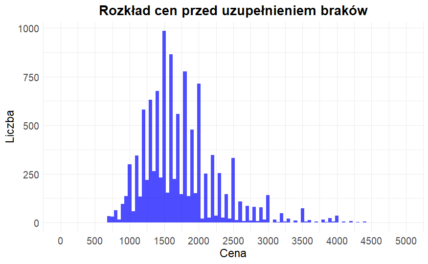

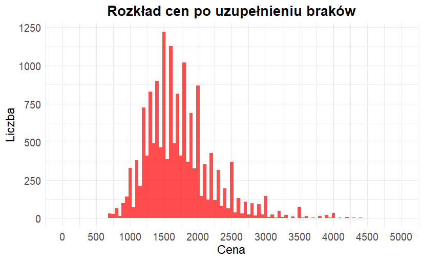

Realizując projekt sprawdzono wiele rozwiązań (dokładnie 20), różniących się głównie hiperparametrami, sposobem łączenia i kolejnością stosowania metod imputacji. Pare początkowych wyników wrzucanych na kaggle.com miało służyć sprawdzeniu jak zmienianie i uszczegóławianie podejścia przybliża wyniki do rzeczywistych. Kilka wyników to te dotyczące zaprezentowanego w raporcie podejścia. Różnią się wartościami paramterów modeli: liczba sąsiadów w metodzie KNN oraz liczba drzew w metodzie lasu losowego. Pomimo tego, że las losowy z większą liczbą drzew gwarantował wyniki najbardziej zbliżone do rzeczywistych, zdecydowano zmniejszyć liczbę drzew dla przyspieszenia obliczeń przy zachowaniu zadowalającego wyniku.

# 4 Podsumowanie

Jak wskazano wyżej LLM ChatGpt został wykorzystany do przeszukania sieci i przyporządkowania obszarów Poznania do odpowiednich dzielnic. Pomimo tego, że polecenie nie zostało wykonane w pełni, to z pewnością zredukowało czas poświęcony na przeszukiwanie źródeł interneowych przez autorkę. W związku z tym doświadczenie można uznać za pozytywne.

Dzięki realizacji projektu autorka raportu nabyła praktyczne umiejętności w wykrywaniu braków i błędów danych oraz dopasowywaniu odpowiednich metod imputacji. Istotna była możliwość przetestowania różnych podejść do braków danych i zobaczenia ich rezultatów. Umożliwiło to praktyczne porównanie działania tych metod. W trakcie realizacji projektu autorka znacząco poprawiła umiejętności posługiwania się językiem R.

# 5 Kody do odtworzenia wyników

Instalacja i wczytywanie pakietów:

```r
options(repos = c(CRAN = "https://cran.r-project.org"))
install.packages("rmarkdown")
install.packages("data.table")
install.packages("dplyr")
install.packages("readxl")
install.packages("stringr")
install.packages("ggplot2")
install.packages("VIM")
install.packages("xtable")
install.packages("naniar")
install.packages("ranger")
install.packages("mice")
library(mice)
library(readxl)
library(VIM)
library(ranger)
library(naniar)
library(ggplot2)
library(data.table)
library(dplyr)
library(xtable)
library(stringr)
pdf.options(encoding = "CP1250")
```

Wczytanie danych:

```r
data_train <- read.csv("C:/Users/kamil/ProjektADN/daneNiekompletneR_V5/mieszkaniaPoznan/train.csv")

data_test <- read.csv("C:/Users/kamil/ProjektADN/daneNiekompletneR_V5/mieszkaniaPoznan/test.csv")
```

Przetwarzanie danych:

```r
#Połączenie danych w jeden zbiór
all_data <- bind_rows(data_train, data_test)

#Powielenie ramki - stworzenie ramki do modyfikacji
all_data_edit <- all_data
```

Sprawdzenie czy wszystkie id są unikalne i logiczności dat:

```r
# Sprawdzenie czy wszystkie id są unikalne
is_unique <- length(all_data$id) == length(unique(all_data$id))
if (is_unique) {
  print("Wszystkie id są unikalne.")
} else {
  print("Są zduplikowane wartości w kolumnie id.")
}
#Wynik: Wszystkie id są unikalne

#Zamiana na typ danych Date
all_data_edit$date_activ <- as.Date(all_data_edit$date_activ)
all_data_edit$date_modif <- as.Date(all_data_edit$date_modif)
all_data_edit$date_expire <- as.Date(all_data_edit$date_expire)

logic_errors_dates <- all_data_edit %>%
  filter(date_activ > date_expire | date_activ > date_modif)
nrow(logic_errors_dates)

#Wniosek: nie ma tego rodzaju błędów w datach

#Znajdowanie braków oznaczonych inaczej niż "NA"
print(all_data_edit %>%
        miss_scan_count(search = list("N/A", "N/a", "missing", " ")), n=40)

#Wartości puste występują w kolumnie "quarter" - zamiana " " na NA
all_data_edit <- all_data_edit %>%
  mutate(quarter = ifelse(quarter == "", NA, quarter))
```

Wstępna wizualizacja braków:

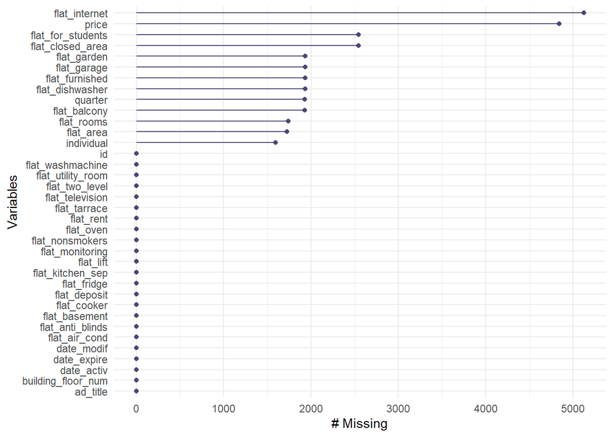

```r
gg_miss_var(all_data_edit)
```

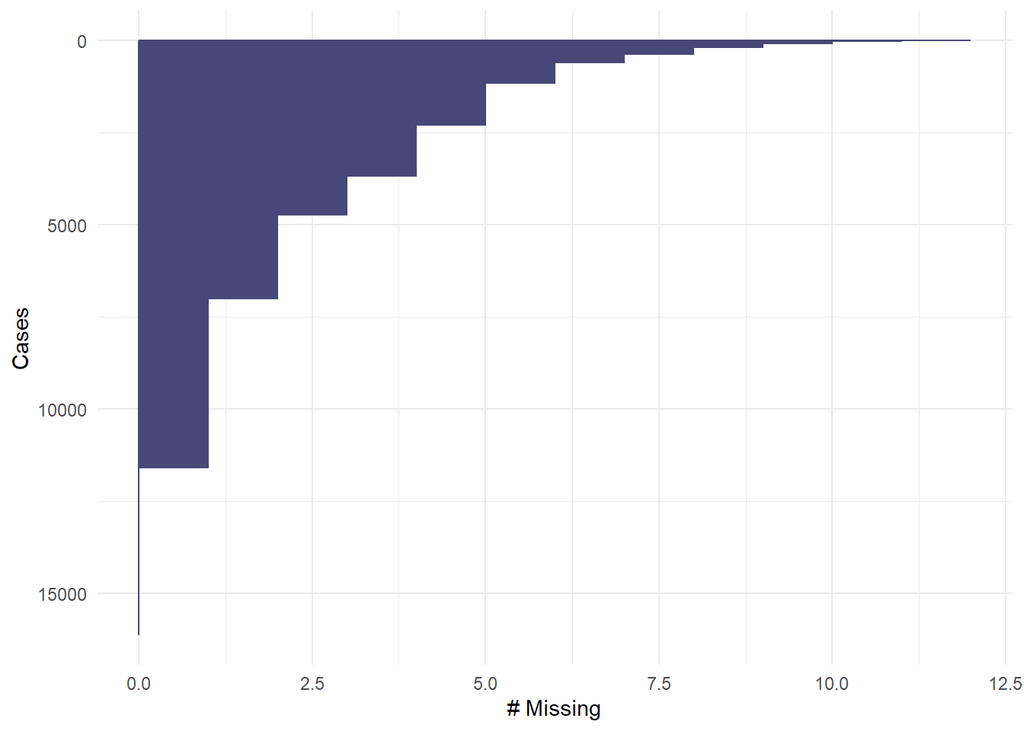

```r
gg_miss_case(all_data_edit)
```

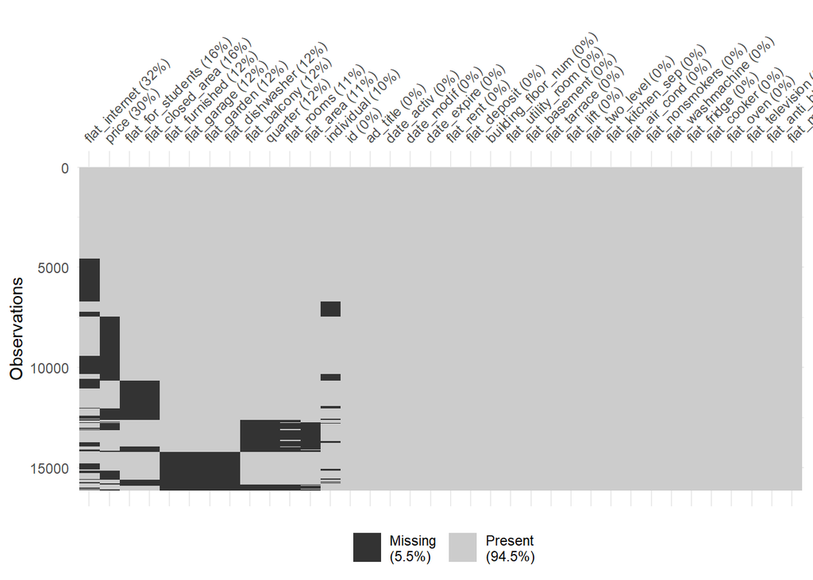

```r
vis_miss(all_data_edit, cluster = TRUE, sort_miss = TRUE)
```

Identyfikacja wartości odstających, nietypowych dla konkretnych zmiennych:

```r
#Krótkie podsumowanie
summary(all_data_edit)
```

```
       id          ad_title           date_activ           date_modif
 Min.   :    1   Length:16139       Min.   :2014-04-05   Min.   :2019-05-02
 1st Qu.: 4110   Class :character   1st Qu.:2019-07-28   1st Qu.:2019-09-30
 Median : 8229   Mode  :character   Median :2020-01-14   Median :2020-03-28
 Mean   : 8223                      Mean   :2019-11-12   Mean   :2020-02-29
 3rd Qu.:12338                      3rd Qu.:2020-06-09   3rd Qu.:2020-07-28
 Max.   :16448                      Max.   :2020-09-25   Max.   :2020-09-26

  date_expire         individual          price        flat_area
 Min.   :2019-06-01   Mode :logical   Min.   : 700   Min.   :-999.00
 1st Qu.:2019-10-25   FALSE:10135     1st Qu.:1350   1st Qu.:  34.00
 Median :2020-04-21   TRUE :4410      Median :1600   Median :  45.00
 Mean   :2020-03-24   NA's :1594      Mean   :1729   Mean   : -63.19
 3rd Qu.:2020-08-21                   3rd Qu.:2000   3rd Qu.:  54.14
 Max.   :2021-04-04                   Max.   :4400   Max.   :2200.00
                                      NA's   :4842   NA's   :1724
   flat_rooms      flat_furnished    flat_rent        flat_deposit
 Min.   :-9.0000   Mode :logical   Min.   :    0.0   Min.   :     0
 1st Qu.: 1.0000   FALSE:7179      1st Qu.:    0.0   1st Qu.:     0
 Median : 2.0000   TRUE :7029      Median :  310.0   Median :  1400
 Mean   : 0.8959   NA's :1931      Mean   :  286.9   Mean   :  1274
 3rd Qu.: 2.0000                   3rd Qu.:  455.5   3rd Qu.:  2000
 Max.   :11.0000                   Max.   :50000.0   Max.   :600067
 NA's   :1742
 flat_for_students building_floor_num flat_balcony    flat_utility_room
 Mode :logical     Min.   : 0.000     Mode :logical   Mode :logical
 FALSE:9892        1st Qu.: 3.000     FALSE:6320      FALSE:15109
 TRUE :3702        Median : 4.000     TRUE :7889      TRUE :1030
 NA's :2545        Mean   : 4.303     NA's :1930
                   3rd Qu.: 5.000
                   Max.   :20.000

 flat_garage     flat_basement   flat_garden     flat_tarrace
 Mode :logical   Mode :logical   Mode :logical   Mode :logical
 FALSE:10156     FALSE:13314     FALSE:13515     FALSE:14873
 TRUE :4052      TRUE :2825      TRUE :693       TRUE :1266
 NA's :1931                      NA's :1931



```

[output cut: 14 more lines]

```


 flat_cooker     flat_oven       flat_internet   flat_television
 Mode :logical   Mode :logical   Mode :logical   Mode :logical
 FALSE:7590      FALSE:8904      FALSE:6358      FALSE:9707
 TRUE :8549      TRUE :7235      TRUE :4659      TRUE :6432
                                 NA's :5122



 flat_anti_blinds flat_monitoring flat_closed_area   quarter
 Mode :logical    Mode :logical   Mode :logical    Length:16139
 FALSE:14934      FALSE:12067     FALSE:10196      Class :character
 TRUE :1205       TRUE :4072      TRUE :3398       Mode  :character
                                  NA's :2545
```

```r
#Wykryte wartości:
  #flat_area - wartości mniejsze od 0 i rzędu tysięcy
  #flat_rooms - wartości mniejsze od 0
  #flat_rent  - 17000 i 50000
  #flat_deposit - 28000 i 600067
  #building_floor_number - pare możliwych wysokich wartości - do weryfikacji z tytułem ogłoszenia
```

Zamiana wartości z wysokim prawdopodobieństwem niepoprawnych na NA:

```r
#wartość flat_area mniejsza od 0 i wieksza od 500 -> NA
all_data_edit <- all_data_edit %>%
  mutate(flat_area = ifelse(flat_area <= 0 | flat_area > 500, NA, flat_area))

#wartość flat_rooms mniejsza od 0 -> NA
all_data_edit <- all_data_edit %>%
  mutate(flat_rooms = ifelse(flat_rooms <= 0, NA, flat_rooms))

#wartość flat_rent jednostkowa lub wieksza od 10000 -> NA
all_data_edit <- all_data_edit %>%
  mutate(flat_rent = ifelse(flat_rent > 0 & flat_rent <= 10 | flat_rent > 10000, NA, flat_rent))

#wartość flat_deposit większa od 15000 -> NA
all_data_edit <- all_data_edit %>%
  mutate(flat_deposit = ifelse(flat_deposit > 15000, NA, flat_deposit))
```

Imputacja dedukcyjna - imputacja danych wywnioskowanych z tytułów ogłoszeń:

```r
#Powielenie ramki danych - dalsza praca na nowej ramce
all_data_regex <- all_data_edit
```

- zmienne logiczne:

```r
#Komentarze nad kodem wskazują, dla jakiej kolumny wykonywane są operacje
#Operacje wykonywane dla kolumn są bardzo podobne, więc dla zachowania przejrzystości zachowano komentarze tylko dla pierwszego przypadku

#individual
#dodanie kolumny individual_cl z danymi dotyczącymi zmiennej individual wywnioskowanych z kolumny ad_title
all_data_regex <- all_data_regex %>%
  mutate(individual_cl = case_when(
    str_detect(str_to_lower(ad_title), "oferta prywatna|osoba prywatna|os\\. prywatn|prywatne|prywatnie|bez pośrednik|bezpo|bez po") ~ TRUE,
    TRUE ~ NA_real_
  ))
#porównanie danych między kolumnami individual i individual_cl. W przypadku braku danych w individual wstawienie danych z individual_cl. Następnie usunięcie roboczej kolumny individual_cl
all_data_regex <- all_data_regex %>%
  mutate(individual = coalesce(individual, individual_cl)) %>%
  select(-individual_cl)
#zapewnienie, że dane w kolumnie individual są typu logicznego
all_data_regex$individual <- as.logical(all_data_regex$individual)

#flat_balcony
all_data_regex <- all_data_regex %>%
  mutate(flat_balcony_cl = case_when(
    str_detect(str_to_lower(ad_title), "balk") ~ TRUE,
    TRUE ~ NA_real_
  ))

all_data_regex <- all_data_regex %>%
  mutate(flat_balcony = if_else(!is.na(flat_balcony_cl), flat_balcony_cl, flat_balcony)) %>%
  select(-flat_balcony_cl)

all_data_regex$flat_balcony <- as.logical(all_data_regex$flat_balcony)

#flat_furnished
extract_furniture <- function(ad_title) {
  ad_title <- tolower(ad_title) # Convert to lowercase
  case_when(
    str_detect(ad_title, "\\bumeblow") ~ TRUE,
    str_detect(ad_title, "\\bmebl") ~ TRUE,
    str_detect(ad_title, "umebl[^\\w]") ~ TRUE,
    str_detect(ad_title, "\\b umeb") ~ TRUE,
    str_detect(ad_title, "\\bumebl\\.") ~ TRUE,
    str_detect(ad_title, "\\bwyposa") ~ TRUE,
    str_detect(ad_title, "\\bnieumebl") ~ FALSE,
    str_detect(ad_title, "\\bbez mebl") ~ FALSE,
    TRUE ~ NA
  )
}

all_data_regex$flat_furnished_cl <- extract_furniture(all_data_regex$ad_title)

all_data_regex <- all_data_regex %>%
  mutate(flat_furnished = if_else(!is.na(flat_furnished_cl), flat_furnished_cl, flat_furnished)) %>%
  select(-flat_furnished_cl)

#flat_for_students
extract_for_students <- function(ad_titles) {
  sapply(ad_titles, function(ad_title) {
    ad_title <- tolower(ad_title)
    contains_student <- str_detect(ad_title, "student")
    if (!contains_student) {
      return(NA)
    }
    return(TRUE)
  })
}
all_data_regex$flat_for_students_cl <- extract_for_students(all_data_regex$ad_title)

all_data_regex <- all_data_regex %>%
  mutate(flat_for_students = if_else(!is.na(flat_for_students_cl), flat_for_students_cl, flat_for_students)) %>%
  select(-flat_for_students_cl)

#flat_garage
extract_garage <- function(ad_titles) {
  sapply(ad_titles, function(ad_title) {
    ad_title <- tolower(ad_title)
    contains_gara <- str_detect(ad_title, "gara")
    if (!contains_gara) {
      return(NA)
    }
    return(TRUE)
  })
}

all_data_regex$flat_garage_cl <- extract_garage(all_data_regex$ad_title)

all_data_regex <- all_data_regex %>%
  mutate(flat_garage = if_else(!is.na(flat_garage_cl), flat_garage_cl, flat_garage)) %>%
  select(-flat_garage_cl)

#flat_garden
extract_garden <- function(ad_titles) {
  sapply(ad_titles, function(ad_title) {
    ad_title <- tolower(ad_title)
    if (str_detect(ad_title, "na ogrod")) {
      return(NA)
    }
    if (str_detect(ad_title, "(ogrod|ogród|z ogrodem|ogródk)")) {
      return(TRUE)
    }
    return(NA)
  })
}

all_data_regex$flat_garden_cl <- extract_garden(all_data_regex$ad_title)

all_data_regex <- all_data_regex %>%
  mutate(flat_garden = if_else(!is.na(flat_garden_cl), flat_garden_cl, flat_garden)) %>%
  select(-flat_garden_cl)

#flat_dishwasher
extract_dishwasher <- function(ad_titles) {
  sapply(ad_titles, function(ad_title) {
    ad_title <- tolower(ad_title)
    contains_dishwasher <- str_detect(ad_title, "zmywar")
    if (!contains_dishwasher) {
      return(NA)
    }
    return(TRUE)
  })
}
all_data_regex$flat_dishwasher_cl <- extract_dishwasher(all_data_regex$ad_title)

all_data_regex <- all_data_regex %>%
  mutate(flat_dishwasher = if_else(!is.na(flat_dishwasher_cl), flat_dishwasher_cl, flat_dishwasher)) %>%
  select(-flat_dishwasher_cl)

#flat_internet
extract_internet <- function(ad_title) {
  ad_title <- tolower(ad_title)
  case_when(
    str_detect(ad_title, "\\bmedia") ~ TRUE,
    str_detect(ad_title, "\\bwifi") ~ TRUE,
    str_detect(ad_title, "\\binternet") ~ TRUE,
    str_detect(ad_title, "\\bintern") ~ TRUE,
    str_detect(ad_title, "\\bwi-fi") ~ TRUE,
    TRUE ~ NA
  )
}

all_data_regex$flat_internet_cl <- extract_internet(all_data_regex$ad_title)

all_data_regex <- all_data_regex %>%
  mutate(flat_internet = if_else(!is.na(flat_internet_cl), flat_internet_cl, flat_internet)) %>%
  select(-flat_internet_cl)

#flat_closed_area
extract_closed_area <- function(ad_titles) {
  sapply(ad_titles, function(ad_title) {
    ad_title <- tolower(ad_title)
    contains_closed_area <- str_detect(ad_title, "zamkn")
    if (!contains_closed_area) {
      return(NA)
    }
    return(TRUE)
  })
}

all_data_regex$flat_closed_area_cl <- extract_closed_area(all_data_regex$ad_title)

all_data_regex <- all_data_regex %>%
  mutate(flat_closed_area = if_else(!is.na(flat_closed_area_cl), flat_closed_area_cl, flat_closed_area)) %>%
  select(-flat_closed_area_cl)

#flat_utility_room
extract_utility_room <- function(ad_titles) {
  sapply(ad_titles, function(ad_title) {
    ad_title <- tolower(ad_title)
    contains_utility_room <- str_detect(ad_title, "gosp")
    if (!contains_utility_room) {
      return(NA)
    }
    return(TRUE)
  })
}

all_data_regex$flat_utility_room_cl <- extract_utility_room(all_data_regex$ad_title)

all_data_regex <- all_data_regex %>%
  mutate(flat_utility_room = if_else(!is.na(flat_utility_room_cl), flat_utility_room_cl, flat_utility_room)) %>%
  select(-flat_utility_room_cl)

#flat_basement
extract_basement <- function(ad_titles) {
  sapply(ad_titles, function(ad_title) {
    ad_title <- tolower(ad_title)
    contains_basement <- str_detect(ad_title, "piwn")
    if (!contains_basement) {
      return(NA)
    }
    return(TRUE)
  })
}

all_data_regex$flat_basement_cl <- extract_basement(all_data_regex$ad_title)

all_data_regex <- all_data_regex %>%
  mutate(flat_basement = if_else(!is.na(flat_basement_cl), flat_basement_cl, flat_basement)) %>%
  select(-flat_basement_cl)

#flat_tarrace
extract_tarrace <- function(ad_titles) {
  sapply(ad_titles, function(ad_title) {
    ad_title <- tolower(ad_title)
    contains_tarrace <- str_detect(ad_title, "taras")
    if (!contains_tarrace) {
      return(NA)
    }
    return(TRUE)
  })
}

all_data_regex$flat_tarrace_cl <- extract_tarrace(all_data_regex$ad_title)

all_data_regex <- all_data_regex %>%
  mutate(flat_tarrace = if_else(!is.na(flat_tarrace_cl), flat_tarrace_cl, flat_tarrace)) %>%
  select(-flat_tarrace_cl)

#flat_lift
extract_lift <- function(ad_titles) {
  sapply(ad_titles, function(ad_title) {
    ad_title <- tolower(ad_title)
    contains_lift <- str_detect(ad_title, "wind")
    if (!contains_lift) {
      return(NA)
    }
    return(TRUE)
  })
}

all_data_regex$flat_lift_cl <- extract_lift(all_data_regex$ad_title)

all_data_regex <- all_data_regex %>%
  mutate(flat_lift = if_else(!is.na(flat_lift_cl), flat_lift_cl, flat_lift)) %>%
  select(-flat_lift_cl)

#flat_two_level
extract_two_level <- function(ad_titles) {
  sapply(ad_titles, function(ad_title) {
    ad_title <- tolower(ad_title)
    contains_two_level <- str_detect(ad_title, "pozio")
    if (!contains_two_level) {
      return(NA)
    }
    return(TRUE)
  })
}

all_data_regex$flat_two_level_cl <- extract_two_level(all_data_regex$ad_title)

all_data_regex <- all_data_regex %>%
  mutate(flat_two_level = if_else(!is.na(flat_two_level_cl), flat_two_level_cl, flat_two_level)) %>%
  select(-flat_two_level_cl)

#flat_air_cond
extract_air_cond <- function(ad_titles) {
  sapply(ad_titles, function(ad_title) {
    ad_title <- tolower(ad_title)
    contains_air_cond <- str_detect(ad_title, "klimatyza")
    if (!contains_air_cond) {
      return(NA)
    }
    return(TRUE)
  })
}

all_data_regex$flat_air_cond_cl <- extract_air_cond(all_data_regex$ad_title)

all_data_regex <- all_data_regex %>%
  mutate(flat_air_cond = if_else(!is.na(flat_air_cond_cl), flat_air_cond_cl, flat_air_cond)) %>%
  select(-flat_air_cond_cl)

#flat_television
extract_flat_tv <- function(ad_title) {
  ad_title <- tolower(ad_title)
  case_when(
    str_detect(ad_title, "\\btv") ~ TRUE,
    str_detect(ad_title, "\\btelew") ~ TRUE,
    TRUE ~ NA
  )
}

all_data_regex$flat_television_cl <- extract_flat_tv(all_data_regex$ad_title)

all_data_regex <- all_data_regex %>%
  mutate(flat_television = if_else(!is.na(flat_television_cl), flat_television_cl, flat_television)) %>%
  select(-flat_television_cl)

#flat_monitoring
extract_flat_monitoring <- function(ad_titles) {
  sapply(ad_titles, function(ad_title) {
    ad_title <- tolower(ad_title)
    contains_flat_monitoring <- str_detect(ad_title, "monitor")
    if (!contains_flat_monitoring) {
      return(NA)
    }
    return(TRUE)
  })
}

all_data_regex$flat_monitoring_cl <- extract_flat_monitoring(all_data_regex$ad_title)

all_data_regex <- all_data_regex %>%
  mutate(flat_monitoring = if_else(!is.na(flat_monitoring_cl), flat_monitoring_cl, flat_monitoring)) %>%
  select(-flat_monitoring_cl)

#flat_kitchen_sep
extract_kitchen_sep <- function(ad_titles) {
  sapply(ad_titles, function(ad_title) {
    ad_title <- tolower(ad_title)
    contains_kitchen_sep <- str_detect(ad_title, "kuchni")
    if (!contains_kitchen_sep) {
      return(NA)
    }
    return(TRUE)
  })
}

all_data_regex$flat_kitchen_sep_cl <- extract_kitchen_sep(all_data_regex$ad_title)

all_data_regex <- all_data_regex %>%
  mutate(flat_kitchen_sep = if_else(!is.na(flat_kitchen_sep_cl), flat_kitchen_sep_cl, flat_kitchen_sep)) %>%
  select(-flat_kitchen_sep_cl)
```

- zmienne numeryczne:

```r
#Komentarze nad kodem wskazują, dla jakiej kolumny wykonywane są operacje

#flat_rent
#funkcja, która zwraca 0, jeśli któreś z wyrażeń powiązanych z brakiem czynszu zostanie znalezione w kolumnie ad_title
extract_rent <- function(ad_title) {
  ad_title <- tolower(ad_title)
  case_when(
    str_detect(ad_title, "\\bbezczynsz") ~ 0,
    str_detect(ad_title, "\\bbez czynsz") ~ 0,
    str_detect(ad_title, "\\bbrak czyn") ~ 0,
    str_detect(ad_title, "\\bbez opłaty czynsz") ~ 0,
    str_detect(ad_title, "\\bbez dodatkowych opłat") ~ 0
  )}
#wywołanie funkcji i umieszczenie wyniku w nowej kolumnie flat_rent_cl
all_data_regex$flat_rent_cl <- extract_rent(all_data_regex$ad_title)
#jeśli w kolumnie flat_rent brakuje danych, wstawienie danych z flat_rent_cl i usunięcie kolumny roboczej flat_rent_cl
all_data_regex <- all_data_regex %>%
  mutate(flat_rent = if_else(!is.na(flat_rent_cl), flat_rent_cl, flat_rent)) %>%
  select(-flat_rent_cl)

#flat_rooms
#podejście podobne jak w przykładzie powyżej
extract_rooms <- function(ad_title) {
  ad_title <- tolower(ad_title)
  patterns_to_numbers <- c(
    "1\\s*-?pok\\.?|1pokoje|1 pokoje|1-pokoje|1 - pokojowe|1-pokojowe|1 pokojowe|1pokojowe|1 - pokojowy|1-pokojowy|1 pokojowy|1pokojowy|1 - pok|1-pok|1pokoj|1 duże pok.|1 przestronne pokoje|1 niezależne pokoje|1 oddzielone pokoje|1 oddzielne pokoje|1 osobne pokoje|1 osobne pok.|1 niezal. pokoje|1 niezależnymi pokojami|\\bjednopok|\\bkawale" = 1,
    "2\\s*-?pok\\.?|2pokoje|2 pokoje|2-pokoje|2 - pokojowe|2-pokojowe|2- pokojowe|2 pokojowe|2pokojowe|2 - pokojowy|2-pokojowy|2 pokojowy|2pokojowy|2 - pok|2-pok|2pokoj|2 duże pok.|2 przestronne pokoje|2 niezależne pokoje|2 oddzielone pokoje|2 oddzielne pokoje|2 osobne pokoje|2 osobne pok.|2 niezal. pokoje|2 niezależnymi pokojami|\\bdwupok|\\bdwa pok|\\bdwa|\\bdwu pok|2-u pok" = 2,
    "3\\s*-?pok\\.?|3pokoje|3 pokoje|3-pokoje|3 - pokojowe|3-pokojowe|3 pokojowe|3 - pokojowy|3-pokojowy|3 pokojowy|3pokojowe|3pokojowy|3 - pok|3pokoj|3 duże pok.|3 przestronne pokoje|3 niezależne pokoje|3 oddzielone pokoje|3 oddzielne pokoje|3 osobne pokoje|3 osobne pok.|3 niezal. pokoje|3 niezależnymi pokojami|\\btrzypok|\\btrzy pok|\\btrzy" = 3,
    "4\\s*-?pok\\.?|4pokoje|4 pokoje|4-pokoje|4 - pokojowe|4-pokojowe|4 pokojowe|4 - pokojowy|4-pokojowy|4 pokojowy|4pokojowe|4pokojowy|4 - pok|4pokoj|4 duże pok.|4 przestronne pokoje|4 niezależne pokoje|4 oddzielone pokoje|4 oddzielne pokoje|4 osobne pokoje|4 osobne pok.|4 niezal. pokoje|4 niezależnymi pokojami|\\bczteropok|\\bcztery pok|\\bcztery" = 4,
    "5\\s*-?pok\\.?|5pokoje|5 pokoje|5-pokoje|5 - pokojowe|5-pokojowe|5 pokojowe|5 - pokojowy|5-pokojowy|5 pokojowy|5pokojowe|5pokojowy|5 - pok|5pokoj|5 duże pok.|5 przestronne pokoje|5 niezależne pokoje|5 oddzielone pokoje|5 oddzielne pokoje|5 osobne pokoje|5 osobne pok.|5 niezal. pokoje|5 niezależnymi pokojami|\\bpięciopok" = 5
  )
  match_room_number <- function(title) {
    for (pattern in names(patterns_to_numbers)) {
      if (str_detect(title, pattern)) {
        return(patterns_to_numbers[pattern])
      }
    }
    return(NA_integer_)
  }
  sapply(ad_title, match_room_number)
}

all_data_regex$flat_rooms_cl <- extract_rooms(all_data_regex$ad_title)

all_data_regex <- all_data_regex %>%
  mutate(flat_rooms = if_else(!is.na(flat_rooms_cl), flat_rooms_cl, flat_rooms)) %>%
  select(-flat_rooms_cl)

#flat_area
#podejście podobne jak w powyższych przykładach z różnicą taką, że do kolumny roboczej wstawiana jest wartość liczbowa przed wykrytym fragmentem tekstu
all_data_regex <- all_data_regex %>%
  mutate(flat_area_cl = str_extract(
    ad_title,
    "(?<!r|mc)\\b(?<!\\d[,.])\\d+[,.]?\\d*\\s?(?=m2|m²|mkw|mkw\\.|m kw\\.|m\\.|m|m,2|sqm)(?!\\d)"
  )) %>%
  mutate(flat_area_cl = str_replace_all(flat_area_cl, ",", ".")) %>%
  mutate(flat_area_cl = as.numeric(flat_area_cl))
all_data_regex <- all_data_regex %>%
  mutate(flat_area_cl = ifelse(flat_area_cl >= 200 | flat_area_cl < 7, NA, flat_area_cl))

all_data_regex <- all_data_regex %>%
  mutate(flat_area = if_else(!is.na(flat_area_cl), flat_area_cl, flat_area)) %>%
  select(-flat_area_cl)

#flat_deposit
#zamiana błędnej wartości na 0 - prawidłowa wartość wywnioskowana z ad_title
all_data_regex$flat_deposit[all_data_regex$id == 15415] <- 0

#price
#procedura podobna jak w poprzednich przykładach, ale wykrywanie przypadków, w których w ad_title podana jest liczba z conajmniej dwoma zerami
all_data_regex <- all_data_regex %>%
  mutate(price_cl = str_extract(ad_title, "\\b\\d*[0]{2}\\b")) %>%
  mutate(price_cl = as.numeric(price_cl))

#usuniecie wartosci ponizej 700 z price_cl (kolumny roboczej)
all_data_regex <- all_data_regex %>%
  mutate(price_cl = ifelse(price_cl < 700, NA, price_cl))
#jak w poprzednich przykładach
all_data_regex <- all_data_regex %>%
  mutate(price = coalesce(price, price_cl)) %>%
  select(-price_cl)
```

- zmienna kategoryczna (“quarter”):

Uwaga: w tym miejscu znajduje się komórka ukryta w wersji html raportu dla zwiększenia jego czytelności. Komórka zawiera dane służące do przypisania dzielnic - część wygenerowana przez LLM jak wskazano w części opisowej raportu.

```r
#I etap
#Zdefiniowanie funkcji do wyszukiwania nazwy dzielnicy w ad_title
extract_district <- function(title, districts) {
  for (district in districts) {
    if (str_detect(title, fixed(district, ignore_case = TRUE))) {
      return(district)
    }
  }
  return(NA)
}

#Wywołanie funkcji i doodanie nowej kolumny 'quarter_cl' z wynikami
all_data_regex <- all_data_regex %>%
  mutate(quarter_cl = ifelse(is.na(quarter), sapply(ad_title, extract_district, districts), quarter))

#Porównanie informacji w oryginalnej kolumnie i kolumnie roboczej, zastąpenie nieznanych wartości oraz usunięcie kolumny roboczej
all_data_regex <- all_data_regex %>%
  mutate(quarter = coalesce(quarter, quarter_cl)) %>%
  select(-quarter_cl)

#II etap
#Przekształcenie na listę
district_list <- setNames(district_mapping$obszar, district_mapping$dzielnica_potocznie)

#Dodanie kolumny roboczej quarter_cl_2 z przyporządkowanymi nazwami obszarów
all_data_regex <- all_data_regex %>%
  mutate(quarter_cl_2 = recode(quarter, !!!district_list))
#Porównanie kolumn, wstawienie poprawionych i usunięcie kolumny roboczej
all_data_regex <- all_data_regex %>%
  mutate(quarter_cl_2 = coalesce(quarter, quarter_cl_2)) %>%
  select(-quarter_cl_2)
```

Wizualizacja braków danych przed przystąpieniem do dalszej imputacji:

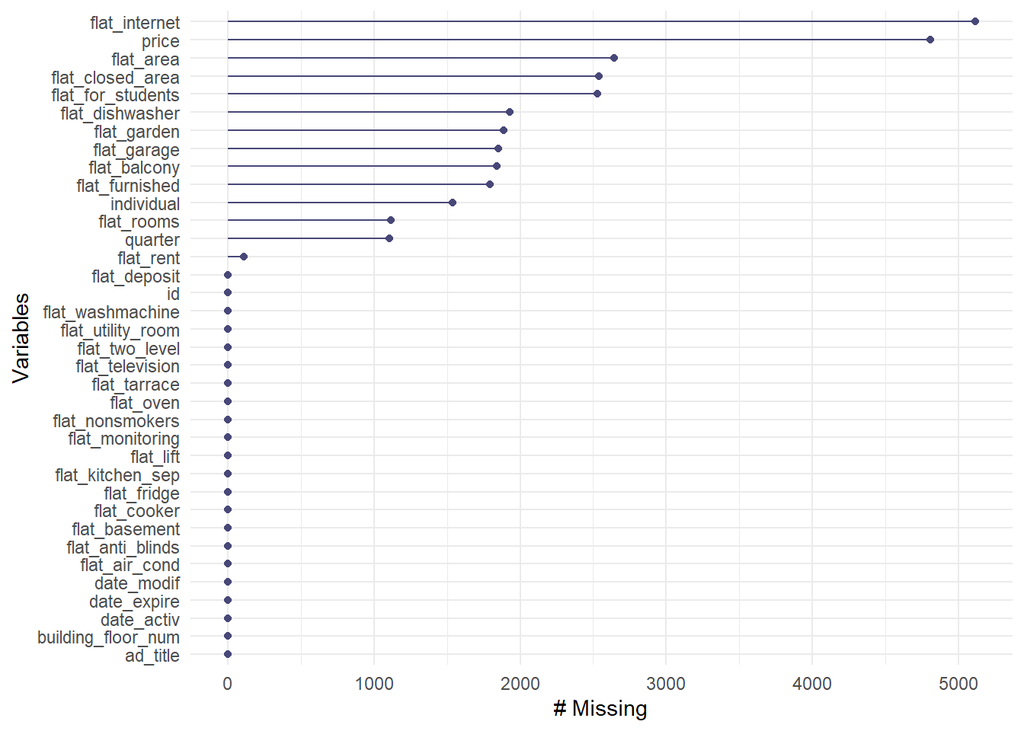

```r
gg_miss_var(all_data_regex)
```

Powielenie wynikowego zbioru danych:

```r
data_for_imputation <- all_data_regex
```

Wyodrębnienie zbioru danych bez tytułów ogłoszeń dla usprawnienia dalszych metod imputacji:

```r
all_data_for_imputation <- data_for_imputation %>% select(-ad_title)
```

Imputacja metodą k-najbliższych sąsiadów dla zmiennej “quarter”:

```r
#wektor zawierający nazwy kolumn z ramki danych, posortowane według liczby brakujących wartości
vars_by_NAs <- all_data_for_imputation %>%
  is.na() %>%
  colSums() %>%
  sort(decreasing = FALSE) %>%
  names()

#imputacja metodą k-najbliższych sąsiadów, gdzie k=3
set.seed(123)
all_data_for_imputation <- all_data_for_imputation %>%
  select(all_of(vars_by_NAs)) %>%
  kNN(k=3, variable = c("quarter"))
```

Imputacja z wykorzystaniem regresji logistycznej dla zmiennych binarnych: “flat_furnished”, “flat_internet” i “flat_closed_area”:

```r
#regresja logistyczna dla niektórych zmiennych binarnych: flat_furnished, flat_internet, flat_closed_area
#flat_furnished
all_data_for_imputation_II <- all_data_for_imputation
missing_flat_furnished <- is.na(all_data_for_imputation$flat_furnished)
logreg_model <- glm(flat_furnished ~ flat_washmachine + flat_fridge + flat_cooker,
                    data = all_data_for_imputation_II, family = binomial)
preds <- predict(logreg_model, type="response")
preds  <- rbinom(length(preds), size = 1, prob = preds)
all_data_for_imputation_II[missing_flat_furnished, "flat_furnished"] <- preds[missing_flat_furnished]

#flat_internet
missing_flat_internet <- is.na(all_data_for_imputation$flat_internet)
logreg_model <- glm(flat_internet ~ flat_television,
                    data = all_data_for_imputation_II, family = binomial)
preds <- predict(logreg_model, type="response")
preds  <- rbinom(length(preds), size = 1, prob = preds)
all_data_for_imputation_II[missing_flat_internet, "flat_internet"] <- preds[missing_flat_internet]

#flat_closed_area
missing_closed_area <- is.na(all_data_for_imputation$flat_closed_area)
logreg_model <- glm(flat_closed_area ~ flat_monitoring,
                    data = all_data_for_imputation_II, family = binomial)
preds <- predict(logreg_model, type="response")
preds  <- rbinom(length(preds), size = 1, prob = preds)
all_data_for_imputation_II[missing_closed_area, "flat_closed_area"] <- preds[missing_closed_area]
```

Imputacja metodą k-najbliższych sąsiadów dla zmiennych binarnych, w których nadal występują braki (k=4):

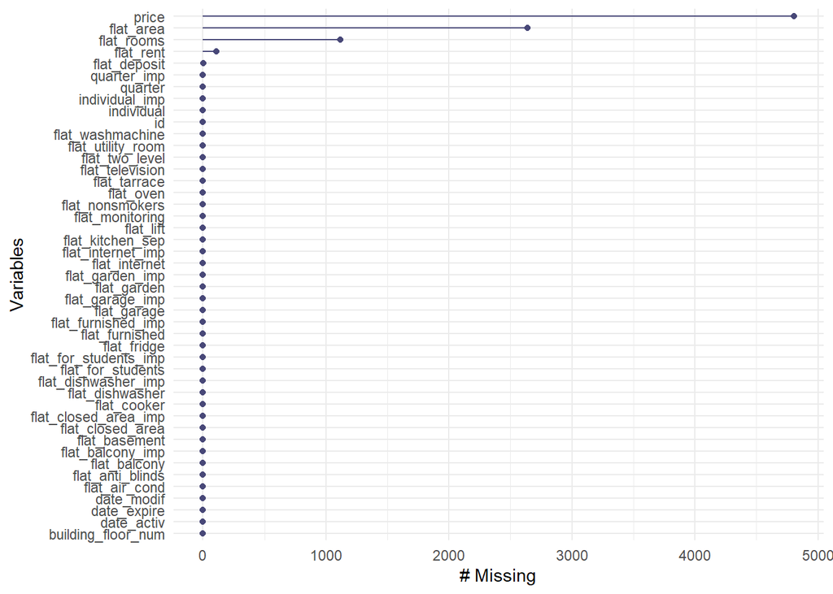

```r
#knn dla reszty zmiennych binarnych
set.seed(123)
all_data_for_imputation_III <- kNN(all_data_for_imputation_II, k=4, variable = c(
  "flat_for_students", "flat_dishwasher", "flat_garden", "flat_garage", "flat_balcony", "flat_internet", "flat_closed_area", "flat_furnished", "individual"))
gg_miss_var(all_data_for_imputation_III)
```

```r
summary(all_data_for_imputation_III)
```

```
       id          date_activ           date_modif          date_expire
 Min.   :    1   Min.   :2014-04-05   Min.   :2019-05-02   Min.   :2019-06-01
 1st Qu.: 4110   1st Qu.:2019-07-28   1st Qu.:2019-09-30   1st Qu.:2019-10-25
 Median : 8229   Median :2020-01-14   Median :2020-03-28   Median :2020-04-21
 Mean   : 8223   Mean   :2019-11-12   Mean   :2020-02-29   Mean   :2020-03-24
 3rd Qu.:12338   3rd Qu.:2020-06-09   3rd Qu.:2020-07-28   3rd Qu.:2020-08-21
 Max.   :16448   Max.   :2020-09-25   Max.   :2020-09-26   Max.   :2021-04-04

 building_floor_num flat_utility_room flat_basement   flat_tarrace
 Min.   : 0.000     Mode :logical     Mode :logical   Mode :logical
 1st Qu.: 3.000     FALSE:15107       FALSE:13301     FALSE:14755
 Median : 4.000     TRUE :1032        TRUE :2838      TRUE :1384
 Mean   : 4.303
 3rd Qu.: 5.000
 Max.   :20.000

 flat_lift       flat_two_level  flat_kitchen_sep flat_air_cond
 Mode :logical   Mode :logical   Mode :logical    Mode :logical
 FALSE:9076      FALSE:15974     FALSE:11595      FALSE:15545
 TRUE :7063      TRUE :165       TRUE :4544       TRUE :594




 flat_nonsmokers flat_washmachine flat_fridge     flat_cooker
 Mode :logical   Mode :logical    Mode :logical   Mode :logical
 FALSE:13851     FALSE:7790       FALSE:7238      FALSE:7590
 TRUE :2288      TRUE :8349       TRUE :8901      TRUE :8549




 flat_oven       flat_television flat_anti_blinds flat_monitoring
 Mode :logical   Mode :logical   Mode :logical    Mode :logical
 FALSE:8904      FALSE:9705      FALSE:14934      FALSE:12065
 TRUE :7235      TRUE :6434      TRUE :1205       TRUE :4074




```

[output cut: 37 more lines]

```



 flat_balcony_imp flat_internet_imp flat_closed_area_imp flat_furnished_imp
 Mode :logical    Mode :logical     Mode :logical        Mode :logical
 FALSE:14298      FALSE:14502       FALSE:15767          FALSE:15915
 TRUE :1841       TRUE :1637        TRUE :372            TRUE :224




 individual_imp
 Mode :logical
 FALSE:14602
 TRUE :1537
```

Imputacja metodą MICE z wykorzystaniem PMM dla brakujących zmiennych numerycznych:

```r
#przygotowanie do imputacji - wybór kolumn uwzględnionych w imputacji
data_for_imputation <- all_data_for_imputation_III[, c("id", "flat_rent", "flat_area", "flat_rooms", "building_floor_num", "flat_utility_room", "flat_basement", "flat_tarrace", "flat_lift", "flat_two_level", "flat_kitchen_sep", "flat_air_cond", "flat_nonsmokers", "flat_washmachine", "flat_fridge", "flat_cooker", "flat_oven", "flat_television", "flat_anti_blinds", "flat_monitoring", "flat_deposit", "individual", "flat_furnished", "flat_balcony", "flat_garage", "flat_garden", "flat_dishwasher", "flat_for_students", "flat_closed_area", "flat_internet")]
```

```r
#imputacja
mice_mod <- mice(data_for_imputation, method = 'pmm', m = 5, seed = 123)

#uzyskanie jednego zestawu danych
completed_data <- complete(mice_mod, 1)
summary(completed_data)
```

[output not shown]

```r
#połączenie danych
completed_data_full <- merge(completed_data, all_data_for_imputation_III[, c("id", "quarter", "date_activ", "date_modif", "date_expire", "price")], by = "id", all.x = TRUE)
```

```r
#kodowanie zmiennych kategorycznych
completed_data_full$quarter <- as.factor(completed_data_full$quarter)
```

```r
#wyekstrahowanie id z oryginalnych danych treningowych i testowych
train_ids <- data_train$id
test_ids <- data_test$id

#podział zaimputowanych danych na treningowe i testowe
train_data <- completed_data_full[completed_data_full$id %in% train_ids, ]
test_data <- completed_data_full[completed_data_full$id %in% test_ids, ]
```

Zastosowanie lasu losowego do predykcji wartości cen:

```r
set.seed(123)
#budowanie modelu lasu losowego na danych treningowych
rf_model_ranger <- ranger(
  formula         = price ~ . - id,
  data            = train_data,
  num.trees       = 1000,
  importance      = 'impurity',
  min.node.size   = 5,
  respect.unordered.factors = "order"
)
#przewidywanie na danych testowych
predictions <- predict(rf_model_ranger, data = test_data)$predictions
```

Zapis wyników do pliku csv:

```r
#dodanie przewidywań do danych data_test
data_test$Predicted_Price <- predictions
#dodanie kolumny z numerem porządkowym
data_test$Order_Number <- seq_len(nrow(data_test))

#ramka danych z wynikami
final_data <- data_test[, c("Order_Number", "Predicted_Price")]
colnames(final_data) <- c("ID", "TARGET")

#zapisywanie wyników do pliku CSV
write.csv(final_data, "output.csv", row.names = FALSE)
```

Wizualizacja rozkładu cen przed predykcją i po niej:

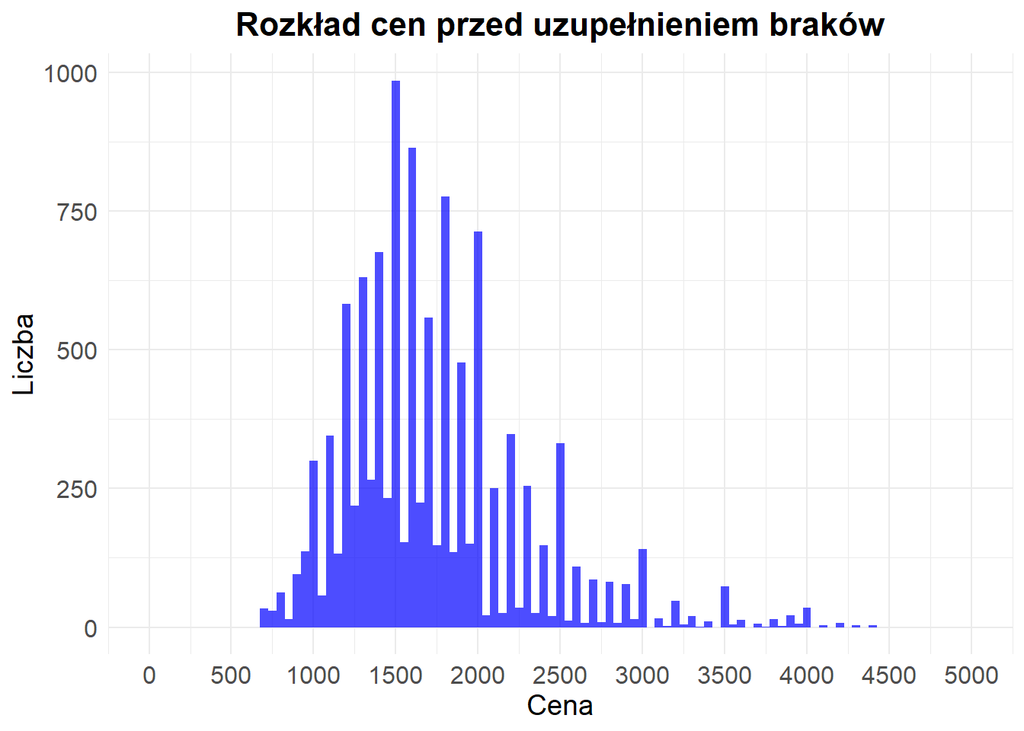

```r
missing_indices <- which(is.na(completed_data_full$price))
#wstawienie przewidywanych wartości do brakujących miejsc
completed_data_full$price[missing_indices] <- predictions
original_data <- completed_data_full
original_data$price[missing_indices] <- NA

# Rozkład przed predykcją
ggplot(data_train, aes(x = price)) +
  geom_histogram(binwidth = 50, fill = "blue", alpha = 0.7) + # Zmniejsz binwidth dla większej szczegółowości
  labs(title = "Rozkład cen przed uzupełnieniem braków", x = "Cena", y = "Liczba") +
  theme_minimal() +
  theme(
    plot.title = element_text(size = 16, face = "bold", hjust = 0.5),
    axis.text = element_text(size = 12),
    axis.title = element_text(size = 14)
  ) +
  scale_x_continuous(limits = c(0, 5000), breaks = seq(0, 5000, by = 500))
```

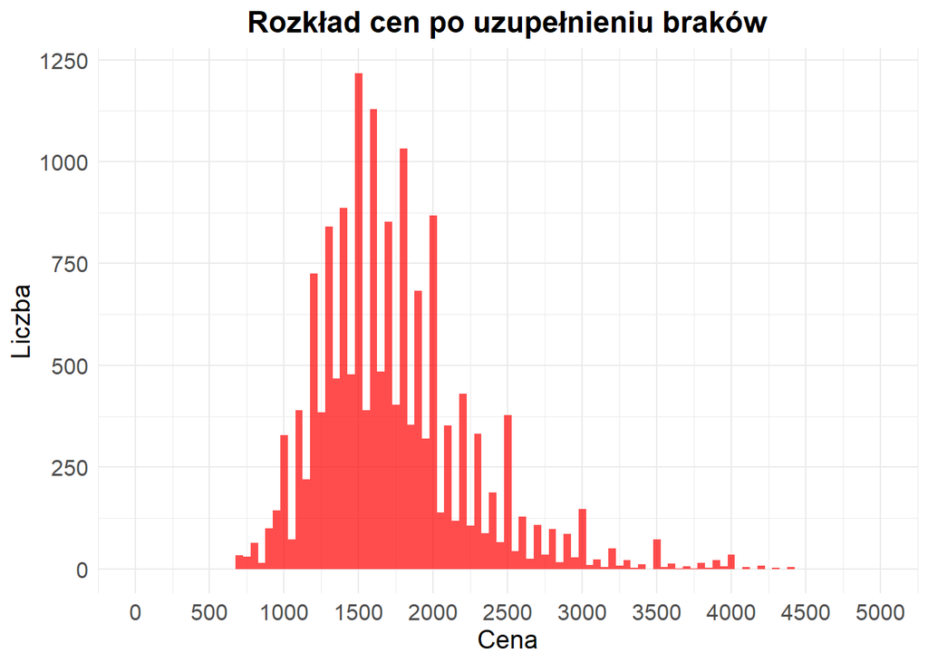

```r
# Rozkład po predykcji
ggplot(completed_data_full, aes(x = price)) +
  geom_histogram(binwidth = 50, fill = "red", alpha = 0.7) +
  labs(title = "Rozkład cen po uzupełnieniu braków", x = "Cena", y = "Liczba") +
  theme_minimal() +
  theme(
    plot.title = element_text(size = 16, face = "bold", hjust = 0.5),
    axis.text = element_text(size = 12),
    axis.title = element_text(size = 14)
  ) +
  scale_x_continuous(limits = c(0, 5000), breaks = seq(0, 5000, by = 500))
```